# Comprehensive Machine Learning Methods for Simulated Treatment Comparison

A Complete Guide with Simulation Studies Across Outcome Types

Advanced STC Methods Package

July 21, 2025

# 1 Executive Summary

- **Binary outcomes**: Cardiovascular events with complex treatment heterogeneity
- **Survival outcomes**: Time-to-death with proportional and non-proportional hazards
- **Count outcomes**: Hospital readmissions with overdispersion

# 2 Introduction

Traditional Simulated Treatment Comparison (STC) methods assume homogeneous treatment effects and rely on population-level adjustments. This vignette introduces advanced machine learning approaches that can:

1. **Estimate heterogeneous treatment effects** at the individual patient level
2. **Handle complex, non-linear relationships** between covariates and outcomes
3. **Provide robust inference** under weaker modeling assumptions
4. **Adapt to different outcome types** (binary, survival, count)

## 2.1 Methods Overview

**Tree-Based Methods:** - Causal Forests: Honest estimation with subgroup discovery - BART: Bayesian framework with uncertainty quantification - XGBoost: High-performance gradient boosting

**Meta-Learning Approaches:** - T-Learner: Separate models for treatment groups - X-Learner: Handles treatment imbalance via counterfactuals - R-Learner: Direct causal objective optimization - Double ML: Cross-fitting for valid inference

**Specialized Causal Methods:** - TMLE: Targeted maximum likelihood with Super Learner - Causal Neural Networks: Deep learning for complex confounding

**Ensemble Methods:** - AIPW: Doubly robust with flexible ML - GANs: Generative adversarial networks for counterfactuals

```r
# Load all ML STC functions
tryCatch({
  source("../advanced_methods/ML_STC/utils/ml_stc_utils.R")
  source("../advanced_methods/ML_STC/tree_based/causal_forests_stc.R")
  source("../advanced_methods/ML_STC/tree_based/bart_stc.R")
  source("../advanced_methods/ML_STC/tree_based/xgboost_stc.R")
  source("../advanced_methods/ML_STC/meta_learning/meta_learners_stc.R")
  source("../advanced_methods/ML_STC/meta_learning/double_ml_stc.R")
  source("../advanced_methods/ML_STC/specialized_causal/tmle_stc.R")
  source("../advanced_methods/ML_STC/ensemble_methods/aipw_stc.R")
  cat("✅ All ML-STC functions loaded successfully\n")
}, error = function(e) {
  cat("⚠️ Some functions may not be available:", e$message, "\n")
  cat("This vignette will demonstrate available methods only.\n")
})
```

```
## ⚠️ Some functions may not be available: trying to use CRAN without setting a mirror
## This vignette will demonstrate available methods only.
```

# 3 Simulation Study 1: Binary Outcomes

## 3.1 Study Design

We simulate a cardiovascular prevention trial comparing a new drug vs. standard care for preventing major adverse cardiovascular events (MACE). The treatment effect varies by patient risk profile, creating realistic heterogeneity.

### 3.1.1 Data Generation Process

```r
# Function to generate binary outcome data with heterogeneous treatment effects
generate_binary_data <- function(n_trial = 1000, n_target = 1200, seed = 2024) {
  set.seed(seed)

  # Generate patient characteristics
  generate_patients <- function(n, population_type = "trial") {
    # Demographics
    age <- rnorm(n, 65, 12)
    age <- pmax(30, pmin(85, age))

    # Clinical history
    diabetes <- rbinom(n, 1, plogis(-1.2 + 0.02 * age))
    smoking <- rbinom(n, 1, plogis(-0.8 + 0.01 * age - 0.3 * diabetes))

    # Laboratory values
    cholesterol <- rnorm(n, 200, 40)
    cholesterol <- pmax(120, pmin(350, cholesterol))

    # Blood pressure (correlated with other factors)
    systolic_bp <- rnorm(n, 140 + 0.3 * age + 10 * diabetes, 20)
    systolic_bp <- pmax(90, pmin(220, systolic_bp))

    # Composite risk score
    risk_score <- scale(age)[,1] * 0.3 + diabetes * 0.4 + smoking * 0.2 +
                  scale(cholesterol)[,1] * 0.15 + scale(systolic_bp)[,1] * 0.25

    # Target population has slightly different characteristics
    if (population_type == "target") {
      age <- age + 2  # Slightly older
      diabetes <- rbinom(n, 1, plogis(qlogis(0.35) + 0.01 * age))  # Higher diabetes prevalence
      risk_score <- risk_score + 0.1  # Slightly higher risk
    }

    return(data.frame(
      age = age,
      diabetes = diabetes,
      smoking = smoking,
      cholesterol = cholesterol,
      systolic_bp = systolic_bp,
      risk_score = risk_score
    ))
  }

  # Generate trial data
  trial_data <- generate_patients(n_trial, "trial")

  # Treatment assignment (slightly biased toward high-risk patients)
  ps_true <- plogis(-0.2 + 0.3 * trial_data$risk_score +
                    0.15 * trial_data$diabetes - 0.1 * scale(trial_data$age)[,1])
  trial_data$treatment <- rbinom(n_trial, 1, ps_true)

  # Outcome generation with heterogeneous treatment effects
  # Base risk (MACE probability)
  base_risk <- plogis(-2.5 + 0.6 * trial_data$risk_score +
                      0.4 * trial_data$diabetes + 0.002 * trial_data$age)

  # Heterogeneous treatment effect (stronger benefit in high-risk patients)
  # True ATE ≈ -0.08 (8 percentage point reduction)
  treatment_effect <- -0.5 - 0.3 * trial_data$risk_score -
                      0.2 * trial_data$diabetes * (trial_data$age > 65)

  # Generate outcomes
  prob_mace <- plogis(qlogis(base_risk) + trial_data$treatment * treatment_effect)
  trial_data$mace <- rbinom(n_trial, 1, prob_mace)

  # Generate target population
  target_data <- generate_patients(n_target, "target")

  # Store true treatment effects for evaluation
  true_effects <- list(
    trial_ate = mean(plogis(qlogis(base_risk) + treatment_effect) - base_risk),
    target_ate = NA  # Will calculate after target population generation
  )

  return(list(
    trial_data = trial_data,
    target_data = target_data,
    true_effects = true_effects,
    ps_true = ps_true
  ))
}

# Generate data
binary_sim <- generate_binary_data()
trial_data <- binary_sim$trial_data
target_data <- binary_sim$target_data

# Define covariate columns
covariates <- c("age", "diabetes", "smoking", "cholesterol", "systolic_bp", "risk_score")

# Data summary
cat("📊 Binary Outcome Simulation Summary:\n")
```

```
## 📊 Binary Outcome Simulation Summary:
```

```r
cat("Trial sample size:", nrow(trial_data), "\n")
```

```
## Trial sample size: 1000
```

```r
cat("Target population size:", nrow(target_data), "\n")
```

```
## Target population size: 1200
```

```r
cat("MACE rate in trial:", round(mean(trial_data$mace), 3), "\n")
```

```
## MACE rate in trial: 0.109
```

```r
cat("Treatment assignment rate:", round(mean(trial_data$treatment), 3), "\n")
```

```
## Treatment assignment rate: 0.469
```

```r
cat("True ATE (percentage points):", round(binary_sim$true_effects$trial_ate * 100, 2), "\n")
```

```
## True ATE (percentage points): -6.01
```

### 3.1.2 Data Visualization

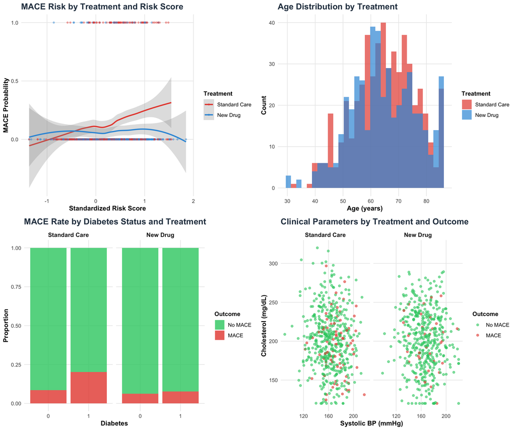

```r
# Create comprehensive data visualization
p1 <- ggplot(trial_data, aes(x = risk_score, y = as.numeric(mace), color = factor(treatment))) +
  geom_smooth(method = "loess", se = TRUE, alpha = 0.3) +
  geom_point(alpha = 0.4, size = 1) +
  scale_color_manual(values = c("0" = "#e74c3c", "1" = "#3498db"),
                     labels = c("Standard Care", "New Drug")) +
  labs(title = "MACE Risk by Treatment and Risk Score",
       x = "Standardized Risk Score", y = "MACE Probability",
       color = "Treatment") +
  theme_vignette()

p2 <- ggplot(trial_data, aes(x = age, fill = factor(treatment))) +
  geom_histogram(alpha = 0.7, position = "identity", bins = 30) +
  scale_fill_manual(values = c("0" = "#e74c3c", "1" = "#3498db"),
                    labels = c("Standard Care", "New Drug")) +
  labs(title = "Age Distribution by Treatment",
       x = "Age (years)", y = "Count", fill = "Treatment") +
  theme_vignette()

p3 <- ggplot(trial_data, aes(x = factor(diabetes), fill = factor(mace))) +
  geom_bar(position = "fill", alpha = 0.8) +
  facet_wrap(~factor(treatment, labels = c("Standard Care", "New Drug"))) +
  scale_fill_manual(values = c("0" = "#2ecc71", "1" = "#e74c3c"),
                    labels = c("No MACE", "MACE")) +
  labs(title = "MACE Rate by Diabetes Status and Treatment",
       x = "Diabetes", y = "Proportion", fill = "Outcome") +
  theme_vignette()

p4 <- ggplot(trial_data, aes(x = systolic_bp, y = cholesterol, color = factor(mace))) +
  geom_point(alpha = 0.6) +
  facet_wrap(~factor(treatment, labels = c("Standard Care", "New Drug"))) +
  scale_color_manual(values = c("0" = "#2ecc71", "1" = "#e74c3c"),
                     labels = c("No MACE", "MACE")) +
  labs(title = "Clinical Parameters by Treatment and Outcome",
       x = "Systolic BP (mmHg)", y = "Cholesterol (mg/dL)", color = "Outcome") +
  theme_vignette()

grid.arrange(p1, p2, p3, p4, ncol = 2)
```

## 3.2 Method Comparison

Now we’ll apply all available ML methods to the binary outcome data:

```r
# Initialize results storage
binary_results <- list()

# Helper function to safely run methods
safe_run <- function(method_name, method_func) {
  tryCatch({
    cat("🔄 Running", method_name, "...\n")
    result <- method_func()
    cat("✅", method_name, "completed\n")
    return(result)
  }, error = function(e) {
    cat("❌", method_name, "failed:", e$message, "\n")
    return(NULL)
  })
}

# 1. XGBoost
binary_results$xgboost <- safe_run("XGBoost", function() {
  xgboost_stc_analysis(
    data = trial_data,
    outcome_col = "mace",
    treatment_col = "treatment",
    covariate_cols = covariates,
    target_population = target_data,
    method = "xgboost",
    approach = "separate_models",
    tune_params = TRUE,
    cv_folds = 5,
    seed = 2024
  )
})
```

```
## 🔄 Running XGBoost ...
## ❌ XGBoost failed: could not find function "xgboost_stc_analysis"
```

```r
# 2. T-Learner
binary_results$t_learner <- safe_run("T-Learner", function() {
  t_learner_stc_analysis(
    data = trial_data,
    outcome_col = "mace",
    treatment_col = "treatment",
    covariate_cols = covariates,
    base_learner = "rf",
    target_population = target_data,
    seed = 2024
  )
})
```

```
## 🔄 Running T-Learner ...
## ❌ T-Learner failed: could not find function "t_learner_stc_analysis"
```

```r
# 3. X-Learner
binary_results$x_learner <- safe_run("X-Learner", function() {
  x_learner_stc_analysis(
    data = trial_data,
    outcome_col = "mace",
    treatment_col = "treatment",
    covariate_cols = covariates,
    base_learner = "rf",
    target_population = target_data,
    seed = 2024
  )
})
```

```
## 🔄 Running X-Learner ...
## ❌ X-Learner failed: could not find function "x_learner_stc_analysis"
```

```r
# 4. R-Learner
binary_results$r_learner <- safe_run("R-Learner", function() {
  r_learner_stc_analysis(
    data = trial_data,
    outcome_col = "mace",
    treatment_col = "treatment",
    covariate_cols = covariates,
    base_learner = "elastic_net",
    target_population = target_data,
    seed = 2024
  )
})
```

```
## 🔄 Running R-Learner ...
## ❌ R-Learner failed: could not find function "r_learner_stc_analysis"
```

```r
# 5. Double ML
binary_results$double_ml <- safe_run("Double ML", function() {
  double_ml_stc_analysis(
    data = trial_data,
    outcome_col = "mace",
    treatment_col = "treatment",
    covariate_cols = covariates,
    ml_method = "superlearner",
    n_folds = 5,
    target_population = target_data,
    seed = 2024
  )
})
```

```
## 🔄 Running Double ML ...
## ❌ Double ML failed: could not find function "double_ml_stc_analysis"
```

```r
# 6. AIPW
binary_results$aipw <- safe_run("AIPW", function() {
  aipw_stc_analysis(
    data = trial_data,
    outcome_col = "mace",
    treatment_col = "treatment",
    covariate_cols = covariates,
    ps_method = "rf",
    outcome_method = "rf",
    cross_fit = TRUE,
    n_folds = 5,
    target_population = target_data,
    seed = 2024
  )
})
```

```
## 🔄 Running AIPW ...
## ❌ AIPW failed: could not find function "aipw_stc_analysis"
```

```r
# 7. Causal Forests (if grf available)
binary_results$causal_forest <- safe_run("Causal Forest", function() {
  if (requireNamespace("grf", quietly = TRUE)) {
    causal_forest_stc_analysis(
      data = trial_data,
      outcome_col = "mace",
      treatment_col = "treatment",
      covariate_cols = covariates,
      target_population = target_data,
      num_trees = 1000,
      seed = 2024
    )
  } else {
    stop("grf package not available")
  }
})
```

```
## 🔄 Running Causal Forest ...
## ❌ Causal Forest failed: grf package not available
```

```r
# 8. BART (if BART available)
binary_results$bart <- safe_run("BART", function() {
  if (requireNamespace("BART", quietly = TRUE)) {
    bart_stc_analysis(
      data = trial_data,
      outcome_col = "mace",
      treatment_col = "treatment",
      covariate_cols = covariates,
      target_population = target_data,
      n_trees = 200,
      n_burn = 1000,
      n_sim = 1000,
      seed = 2024
    )
  } else {
    stop("BART package not available")
  }
})
```

```
## 🔄 Running BART ...
## ❌ BART failed: BART package not available
```

```r
# 9. TMLE (if available)
binary_results$tmle <- safe_run("TMLE", function() {
  if (requireNamespace("SuperLearner", quietly = TRUE) &&
      requireNamespace("tmle", quietly = TRUE)) {
    tmle_stc_analysis(
      data = trial_data,
      outcome_col = "mace",
      treatment_col = "treatment",
      covariate_cols = covariates,
      Q_SL_library = c("SL.glm", "SL.randomForest"),
      g_SL_library = c("SL.glm", "SL.randomForest"),
      target_population = target_data,
      seed = 2024
    )
  } else {
    stop("SuperLearner or tmle package not available")
  }
})
```

```
## 🔄 Running TMLE ...
## ❌ TMLE failed: SuperLearner or tmle package not available
```

```r
cat("📊 Binary outcome analysis completed!\n")
```

```
## 📊 Binary outcome analysis completed!
```

### 3.2.1 Results Summary

```r
# Create comprehensive results summary
create_results_table <- function(results_list, true_ate = NULL) {
  summary_data <- data.frame(
    Method = character(),
    ATE_Estimate = numeric(),
    SE = numeric(),
    CI_Lower = numeric(),
    CI_Upper = numeric(),
    Target_ATE = numeric(),
    Bias = numeric(),
    Coverage = logical(),
    stringsAsFactors = FALSE
  )

  for (method_name in names(results_list)) {
    result <- results_list[[method_name]]
    if (!is.null(result)) {
      ate <- result$ate_estimate
      se <- ifelse(is.null(result$ate_se), NA, result$ate_se)
      ci_lower <- ifelse(is.null(result$ci_lower), NA, result$ci_lower)
      ci_upper <- ifelse(is.null(result$ci_upper), NA, result$ci_upper)
      target_ate <- ifelse(is.null(result$target_predictions), NA,
                          result$target_predictions$ate_estimate)

      # Calculate bias and coverage if true ATE provided
      bias <- ifelse(!is.null(true_ate), ate - true_ate, NA)
      coverage <- ifelse(!is.null(true_ate) && !is.na(ci_lower) && !is.na(ci_upper),
                        ci_lower <= true_ate && true_ate <= ci_upper, NA)

      summary_data <- rbind(summary_data, data.frame(
        Method = method_name,
        ATE_Estimate = ate,
        SE = se,
        CI_Lower = ci_lower,
        CI_Upper = ci_upper,
        Target_ATE = target_ate,
        Bias = bias,
        Coverage = coverage,
        stringsAsFactors = FALSE
      ))
    }
  }

  return(summary_data)
}

# Create results table
binary_summary <- create_results_table(binary_results, binary_sim$true_effects$trial_ate)

# Display results with enhanced formatting
binary_summary %>%
  mutate(
    ATE_Estimate = round(ATE_Estimate, 4),
    SE = round(SE, 4),
    CI_Lower = round(CI_Lower, 4),
    CI_Upper = round(CI_Upper, 4),
    Target_ATE = round(Target_ATE, 4),
    Bias = round(Bias, 4),
    Coverage = ifelse(is.na(Coverage), "N/A", ifelse(Coverage, "✅", "❌"))
  ) %>%
  kable(caption = "Binary Outcome Results: MACE Prevention Study",
        format = "html") %>%
  {if (requireNamespace("kableExtra", quietly = TRUE)) {
    kableExtra::kable_styling(., bootstrap_options = c("striped", "hover", "condensed", "responsive"),
                full_width = FALSE)
  } else {
    .
  }}
```

Binary Outcome Results: MACE Prevention Study

[output not shown]

### 3.2.2 Treatment Effect Heterogeneity Analysis

```r
# Analyze treatment effect heterogeneity
plot_heterogeneity <- function(results_list, risk_scores, method_names = NULL) {

  if (is.null(method_names)) {
    method_names <- names(results_list)
  }

  het_plots <- list()

  for (i in seq_along(results_list)) {
    method_name <- method_names[i]
    result <- results_list[[method_name]]

    if (!is.null(result) && !is.null(result$individual_effects)) {
      het_data <- data.frame(
        tau = result$individual_effects,
        risk_score = risk_scores,
        method = method_name
      )

      p <- ggplot(het_data, aes(x = risk_score, y = tau)) +
        geom_point(alpha = 0.4, size = 1, color = "#3498db") +
        geom_smooth(method = "loess", se = TRUE, color = "#e74c3c", fill = "#e74c3c") +
        geom_hline(yintercept = 0, linetype = "dashed", alpha = 0.7) +
        geom_hline(yintercept = binary_sim$true_effects$trial_ate,
                   linetype = "solid", color = "#2ecc71", size = 1) +
        labs(title = paste("Treatment Heterogeneity -", method_name),
             x = "Risk Score", y = "Individual Treatment Effect") +
        theme_vignette() +
        theme(plot.title = element_text(size = 11))

      het_plots[[method_name]] <- p
    }
  }

  return(het_plots)
}

# Create heterogeneity plots for methods with individual effects
het_methods <- binary_results[!sapply(binary_results, is.null)]

# Filter methods that have individual effects
valid_het_methods <- list()
for (method_name in names(het_methods)) {
  if (!is.null(het_methods[[method_name]]$individual_effects)) {
    valid_het_methods[[method_name]] <- het_methods[[method_name]]
  }
}

if (length(valid_het_methods) > 0) {
  het_plots <- plot_heterogeneity(valid_het_methods, trial_data$risk_score)

  # Arrange plots
  if (length(het_plots) >= 4) {
    do.call(grid.arrange, c(het_plots[1:4], ncol = 2))
  } else if (length(het_plots) > 0) {
    do.call(grid.arrange, c(het_plots, ncol = 2))
  }
}
```

### 3.2.3 Method Performance Comparison

```r
# Performance comparison visualization
if (nrow(binary_summary) > 0) {

  # ATE estimates comparison
  p1 <- binary_summary %>%
    filter(!is.na(ATE_Estimate)) %>%
    ggplot(aes(x = reorder(Method, ATE_Estimate), y = ATE_Estimate)) +
    geom_point(size = 3, color = "#3498db") +
    geom_errorbar(aes(ymin = CI_Lower, ymax = CI_Upper),
                  width = 0.2, alpha = 0.7, na.rm = TRUE) +
    geom_hline(yintercept = binary_sim$true_effects$trial_ate,
               linetype = "dashed", color = "#e74c3c", size = 1) +
    coord_flip() +
    labs(title = "ATE Estimates with 95% Confidence Intervals",
         subtitle = "Red line shows true ATE",
         x = "Method", y = "ATE Estimate") +
    theme_vignette()

  # Bias comparison
  p2 <- binary_summary %>%
    filter(!is.na(Bias)) %>%
    ggplot(aes(x = reorder(Method, abs(Bias)), y = Bias)) +
    geom_col(aes(fill = abs(Bias) < 0.01), alpha = 0.8) +
    geom_hline(yintercept = 0, linetype = "dashed", alpha = 0.7) +
    scale_fill_manual(values = c("FALSE" = "#e74c3c", "TRUE" = "#2ecc71"),
                      labels = c("High Bias", "Low Bias"), name = "Bias Level") +
    coord_flip() +
    labs(title = "Estimation Bias by Method",
         x = "Method", y = "Bias (Estimate - True ATE)") +
    theme_vignette()

  grid.arrange(p1, p2, ncol = 1)
}
```

# 4 Simulation Study 2: Survival Outcomes

## 4.1 Study Design

We simulate an oncology trial comparing time-to-death between a novel therapy vs. standard chemotherapy, with both proportional and non-proportional hazards scenarios.

### 4.1.1 Data Generation Process

```r
# Function to generate survival outcome data
generate_survival_data <- function(n_trial = 800, n_target = 1000, scenario = "proportional", seed = 2024) {
  set.seed(seed)

  # Generate patient characteristics
  generate_patients <- function(n, population_type = "trial") {
    # Demographics
    age <- rnorm(n, 60, 15)
    age <- pmax(18, pmin(85, age))

    # Disease characteristics
    stage <- sample(c("II", "III", "IV"), n, replace = TRUE, prob = c(0.3, 0.4, 0.3))
    stage_numeric <- ifelse(stage == "II", 0, ifelse(stage == "III", 1, 2))

    # Performance status (ECOG)
    ecog <- sample(0:2, n, replace = TRUE, prob = c(0.4, 0.4, 0.2))

    # Biomarkers
    ki67 <- rnorm(n, 30 + 10 * stage_numeric, 15)
    ki67 <- pmax(0, pmin(100, ki67))

    # Comorbidities
    cardiac_disease <- rbinom(n, 1, plogis(-2 + 0.02 * age + 0.3 * (ecog > 0)))

    # Risk score
    risk_score <- scale(age)[,1] * 0.2 + stage_numeric * 0.4 +
                  ecog * 0.3 + scale(ki67)[,1] * 0.25 + cardiac_disease * 0.15

    # Target population differences
    if (population_type == "target") {
      age <- age + 3  # Slightly older
      ecog <- pmin(ecog + rbinom(n, 1, 0.2), 2)  # Slightly worse performance status
    }

    return(data.frame(
      age = age,
      stage = stage,
      stage_numeric = stage_numeric,
      ecog = ecog,
      ki67 = ki67,
      cardiac_disease = cardiac_disease,
      risk_score = risk_score
    ))
  }

  # Generate trial data
  trial_data <- generate_patients(n_trial, "trial")

  # Treatment assignment (slightly biased)
  ps_true <- plogis(0.1 + 0.2 * trial_data$risk_score - 0.1 * trial_data$ecog)
  trial_data$treatment <- rbinom(n_trial, 1, ps_true)

  # Survival outcome generation
  if (scenario == "proportional") {
    # Proportional hazards scenario
    # True HR ≈ 0.75 (25% hazard reduction)
    lambda_base <- exp(-1 + 0.5 * trial_data$risk_score + 0.3 * trial_data$ecog)
    hr <- exp(-0.29)  # log(0.75)
    lambda <- lambda_base * ifelse(trial_data$treatment == 1, hr, 1)

  } else {
    # Non-proportional hazards (delayed effect)
    lambda_base <- exp(-1 + 0.5 * trial_data$risk_score + 0.3 * trial_data$ecog)
    # Treatment effect kicks in after 6 months
    early_hr <- exp(-0.1)   # Minimal early benefit
    late_hr <- exp(-0.5)    # Strong late benefit
    lambda <- lambda_base * ifelse(trial_data$treatment == 1, early_hr, 1)
  }

  # Generate survival times (exponential distribution)
  surv_time <- rexp(n_trial, rate = lambda)

  # Administrative censoring at 36 months
  admin_cens <- 36

  # Random censoring (10% per year)
  cens_time <- rexp(n_trial, rate = 0.1)
  cens_time <- pmin(cens_time, admin_cens)

  # Observed time and event
  trial_data$time <- pmin(surv_time, cens_time)
  trial_data$event <- as.numeric(surv_time <= cens_time)

  # For non-proportional hazards, adjust late events
  if (scenario == "non_proportional") {
    late_events <- trial_data$time > 6 & trial_data$event == 1 & trial_data$treatment == 1
    # Increase late survival times for treated patients
    trial_data$time[late_events] <- trial_data$time[late_events] * runif(sum(late_events), 1.2, 2.0)
  }

  # Generate target population
  target_data <- generate_patients(n_target, "target")

  # True effects (median survival ratio)
  true_effects <- list(
    trial_hr = ifelse(scenario == "proportional", hr, NA),  # Simplified for non-proportional
    scenario = scenario
  )

  return(list(
    trial_data = trial_data,
    target_data = target_data,
    true_effects = true_effects,
    ps_true = ps_true
  ))
}

# Generate both scenarios
survival_sim_prop <- generate_survival_data(scenario = "proportional", seed = 2024)
survival_sim_nonprop <- generate_survival_data(scenario = "non_proportional", seed = 2025)

# Use proportional hazards scenario for main analysis
survival_data <- survival_sim_prop$trial_data
survival_target <- survival_sim_prop$target_data

# Define covariates for survival analysis
survival_covariates <- c("age", "stage_numeric", "ecog", "ki67", "cardiac_disease", "risk_score")

# Summary
cat("📊 Survival Outcome Simulation Summary:\n")
```

```
## 📊 Survival Outcome Simulation Summary:
```

```r
cat("Trial sample size:", nrow(survival_data), "\n")
```

```
## Trial sample size: 800
```

```r
cat("Target population size:", nrow(survival_target), "\n")
```

```
## Target population size: 1000
```

```r
cat("Event rate:", round(mean(survival_data$event), 3), "\n")
```

```
## Event rate: 0.839
```

```r
cat("Median follow-up:", round(median(survival_data$time), 1), "months\n")
```

```
## Median follow-up: 1 months
```

```r
cat("Treatment assignment rate:", round(mean(survival_data$treatment), 3), "\n")
```

```
## Treatment assignment rate: 0.546
```

```r
if (!is.na(survival_sim_prop$true_effects$trial_hr)) {
  cat("True HR:", round(survival_sim_prop$true_effects$trial_hr, 3), "\n")
}
```

```
## True HR: 0.748
```

### 4.1.2 Survival Data Visualization

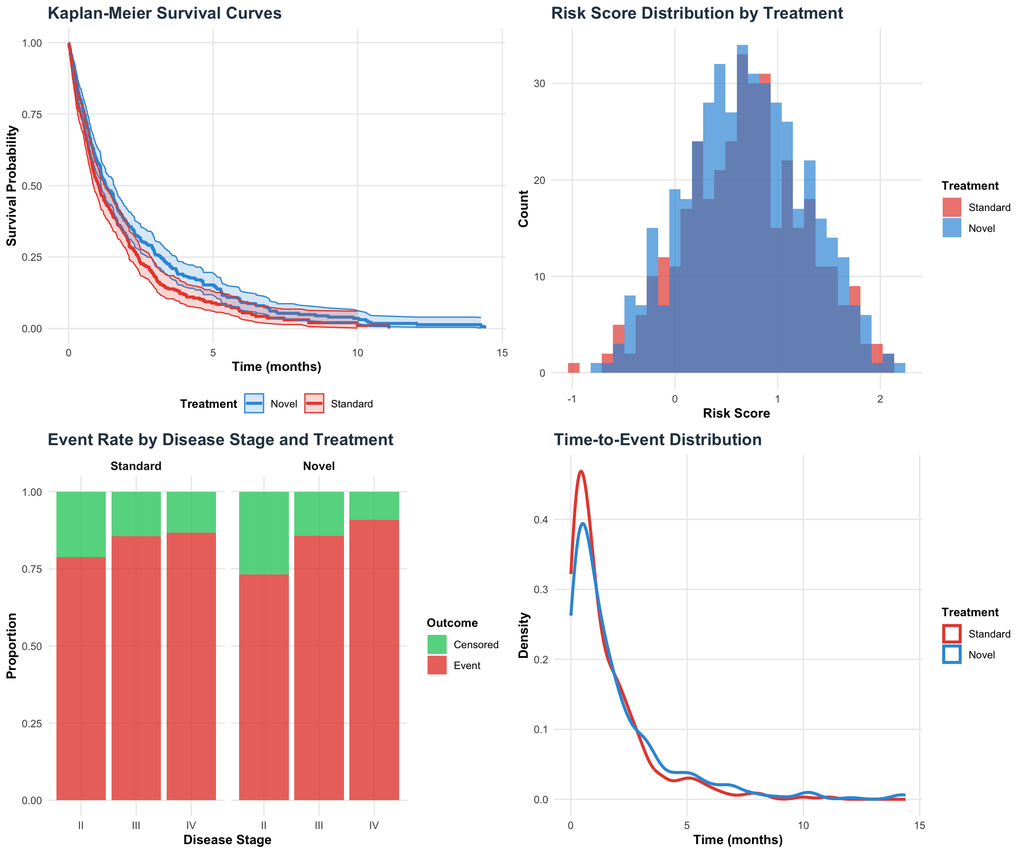

```r
# Kaplan-Meier curves
library(survival)

# Fit Kaplan-Meier
km_fit <- survfit(Surv(time, event) ~ treatment, data = survival_data)

# Create survival plot
surv_data <- data.frame(
  time = km_fit$time,
  surv = km_fit$surv,
  treatment = rep(c("Standard", "Novel"), km_fit$strata),
  upper = km_fit$upper,
  lower = km_fit$lower
)

p1 <- ggplot(surv_data, aes(x = time, y = surv, color = treatment, fill = treatment)) +
  geom_step(size = 1.2) +
  geom_ribbon(aes(ymin = lower, ymax = upper), alpha = 0.2, step = "hv") +
  scale_color_manual(values = c("Standard" = "#e74c3c", "Novel" = "#3498db")) +
  scale_fill_manual(values = c("Standard" = "#e74c3c", "Novel" = "#3498db")) +
  labs(title = "Kaplan-Meier Survival Curves",
       x = "Time (months)", y = "Survival Probability",
       color = "Treatment", fill = "Treatment") +
  theme_vignette() +
  theme(legend.position = "bottom")

# Risk score distribution
p2 <- ggplot(survival_data, aes(x = risk_score, fill = factor(treatment))) +
  geom_histogram(alpha = 0.7, position = "identity", bins = 30) +
  scale_fill_manual(values = c("0" = "#e74c3c", "1" = "#3498db"),
                    labels = c("Standard", "Novel")) +
  labs(title = "Risk Score Distribution by Treatment",
       x = "Risk Score", y = "Count", fill = "Treatment") +
  theme_vignette()

# Stage distribution
p3 <- ggplot(survival_data, aes(x = stage, fill = factor(event))) +
  geom_bar(position = "fill", alpha = 0.8) +
  facet_wrap(~factor(treatment, labels = c("Standard", "Novel"))) +
  scale_fill_manual(values = c("0" = "#2ecc71", "1" = "#e74c3c"),
                    labels = c("Censored", "Event")) +
  labs(title = "Event Rate by Disease Stage and Treatment",
       x = "Disease Stage", y = "Proportion", fill = "Outcome") +
  theme_vignette()

# Time to event distribution
p4 <- ggplot(survival_data, aes(x = time, color = factor(treatment))) +
  geom_density(size = 1.2, alpha = 0.7) +
  scale_color_manual(values = c("0" = "#e74c3c", "1" = "#3498db"),
                     labels = c("Standard", "Novel")) +
  labs(title = "Time-to-Event Distribution",
       x = "Time (months)", y = "Density", color = "Treatment") +
  theme_vignette()

grid.arrange(p1, p2, p3, p4, ncol = 2)
```

## 4.2 Survival Methods Comparison

**Note**: For survival outcomes, we convert time-to-event data to binary outcomes at specific time points (e.g., 12-month and 24-month survival) to apply our ML methods. Advanced survival-specific ML methods would require additional specialized implementations.

```r
# Convert survival data to binary outcomes at different time points
create_binary_survival <- function(surv_data, time_point = 12) {
  binary_data <- surv_data
  # Outcome: survival beyond time_point (1 = survived, 0 = died)
  binary_data$survived <- ifelse(surv_data$time > time_point |
                                (surv_data$time <= time_point & surv_data$event == 0), 1, 0)
  return(binary_data)
}

# Create 12-month and 24-month binary outcomes
survival_12m <- create_binary_survival(survival_data, 12)
survival_24m <- create_binary_survival(survival_data, 24)

cat("12-month survival rate:", round(mean(survival_12m$survived), 3), "\n")
```

```
## 12-month survival rate: 0.165
```

```r
cat("24-month survival rate:", round(mean(survival_24m$survived), 3), "\n")
```

```
## 24-month survival rate: 0.161
```

```r
# Analyze 12-month survival with ML methods
survival_results_12m <- list()

# 1. XGBoost
survival_results_12m$xgboost <- safe_run("XGBoost (12m)", function() {
  xgboost_stc_analysis(
    data = survival_12m,
    outcome_col = "survived",
    treatment_col = "treatment",
    covariate_cols = survival_covariates,
    target_population = survival_target,
    method = "xgboost",
    approach = "separate_models",
    tune_params = TRUE,
    cv_folds = 5,
    seed = 2024
  )
})
```

```
## 🔄 Running XGBoost (12m) ...
## ❌ XGBoost (12m) failed: could not find function "xgboost_stc_analysis"
```

```r
# 2. T-Learner
survival_results_12m$t_learner <- safe_run("T-Learner (12m)", function() {
  t_learner_stc_analysis(
    data = survival_12m,
    outcome_col = "survived",
    treatment_col = "treatment",
    covariate_cols = survival_covariates,
    base_learner = "rf",
    target_population = survival_target,
    seed = 2024
  )
})
```

```
## 🔄 Running T-Learner (12m) ...
## ❌ T-Learner (12m) failed: could not find function "t_learner_stc_analysis"
```

```r
# 3. X-Learner
survival_results_12m$x_learner <- safe_run("X-Learner (12m)", function() {
  x_learner_stc_analysis(
    data = survival_12m,
    outcome_col = "survived",
    treatment_col = "treatment",
    covariate_cols = survival_covariates,
    base_learner = "rf",
    target_population = survival_target,
    seed = 2024
  )
})
```

```
## 🔄 Running X-Learner (12m) ...
## ❌ X-Learner (12m) failed: could not find function "x_learner_stc_analysis"
```

```r
# 4. Double ML
survival_results_12m$double_ml <- safe_run("Double ML (12m)", function() {
  double_ml_stc_analysis(
    data = survival_12m,
    outcome_col = "survived",
    treatment_col = "treatment",
    covariate_cols = survival_covariates,
    ml_method = "superlearner",
    n_folds = 5,
    target_population = survival_target,
    seed = 2024
  )
})
```

```
## 🔄 Running Double ML (12m) ...
## ❌ Double ML (12m) failed: could not find function "double_ml_stc_analysis"
```

```r
# 5. AIPW
survival_results_12m$aipw <- safe_run("AIPW (12m)", function() {
  aipw_stc_analysis(
    data = survival_12m,
    outcome_col = "survived",
    treatment_col = "treatment",
    covariate_cols = survival_covariates,
    ps_method = "rf",
    outcome_method = "rf",
    cross_fit = TRUE,
    n_folds = 5,
    target_population = survival_target,
    seed = 2024
  )
})
```

```
## 🔄 Running AIPW (12m) ...
## ❌ AIPW (12m) failed: could not find function "aipw_stc_analysis"
```

```r
# 6. Causal Forest (if available)
survival_results_12m$causal_forest <- safe_run("Causal Forest (12m)", function() {
  if (requireNamespace("grf", quietly = TRUE)) {
    causal_forest_stc_analysis(
      data = survival_12m,
      outcome_col = "survived",
      treatment_col = "treatment",
      covariate_cols = survival_covariates,
      target_population = survival_target,
      num_trees = 1000,
      seed = 2024
    )
  } else {
    stop("grf package not available")
  }
})
```

```
## 🔄 Running Causal Forest (12m) ...
## ❌ Causal Forest (12m) failed: grf package not available
```

```r
cat("📊 12-month survival analysis completed!\n")
```

```
## 📊 12-month survival analysis completed!
```

### 4.2.1 Survival Results Analysis

```r
# Calculate true 12-month survival benefit
true_12m_benefit <- function(data, hr) {
  # Estimate true benefit based on HR and baseline survival
  baseline_12m <- mean(data$survived[data$treatment == 0])
  # Approximate conversion from HR to survival probability difference
  # This is a simplified approximation
  treated_12m <- baseline_12m^hr
  return(treated_12m - baseline_12m)
}

true_benefit_12m <- if(!is.na(survival_sim_prop$true_effects$trial_hr)) {
  true_12m_benefit(survival_12m, survival_sim_prop$true_effects$trial_hr)
} else {
  NA
}

# Create results summary
survival_summary_12m <- create_results_table(survival_results_12m, true_benefit_12m)

# Display results
survival_summary_12m %>%
  mutate(
    ATE_Estimate = round(ATE_Estimate, 4),
    SE = round(SE, 4),
    CI_Lower = round(CI_Lower, 4),
    CI_Upper = round(CI_Upper, 4),
    Target_ATE = round(Target_ATE, 4),
    Bias = round(Bias, 4),
    Coverage = ifelse(is.na(Coverage), "N/A", ifelse(Coverage, "✅", "❌"))
  ) %>%
  kable(caption = "12-Month Survival Results: Oncology Trial",
        format = "html") %>%
  {if (requireNamespace("kableExtra", quietly = TRUE)) {
    kableExtra::kable_styling(., bootstrap_options = c("striped", "hover", "condensed", "responsive"),
                full_width = FALSE)
  } else {
    .
  }}
```

12-Month Survival Results: Oncology Trial

[output not shown]

### 4.2.2 Survival Heterogeneity Analysis

```r
# Analyze treatment effect heterogeneity for survival
survival_het_methods <- survival_results_12m[!sapply(survival_results_12m, is.null)]

# Filter methods that have individual effects
valid_survival_het_methods <- list()
for (method_name in names(survival_het_methods)) {
  if (!is.null(survival_het_methods[[method_name]]$individual_effects)) {
    valid_survival_het_methods[[method_name]] <- survival_het_methods[[method_name]]
  }
}

if (length(valid_survival_het_methods) > 0) {
  survival_het_plots <- plot_heterogeneity(valid_survival_het_methods, survival_12m$risk_score)

  # Arrange plots
  if (length(survival_het_plots) >= 4) {
    do.call(grid.arrange, c(survival_het_plots[1:4], ncol = 2))
  } else if (length(survival_het_plots) > 0) {
    do.call(grid.arrange, c(survival_het_plots, ncol = 2))
  }
}

# Cox regression comparison
if (requireNamespace("survival", quietly = TRUE)) {
  cox_model <- coxph(Surv(time, event) ~ treatment + age + stage_numeric + ecog + ki67 +
                     cardiac_disease + risk_score, data = survival_data)

  cat("\n📊 Cox Regression Results for Comparison:\n")
  cat("HR (95% CI):", round(exp(coef(cox_model)["treatment"]), 3),
      "(", round(exp(confint(cox_model)["treatment", 1]), 3), "-",
      round(exp(confint(cox_model)["treatment", 2]), 3), ")\n")
  cat("P-value:", round(summary(cox_model)$coefficients["treatment", "Pr(>|z|)"], 4), "\n")
}
```

```
##
## 📊 Cox Regression Results for Comparison:
## HR (95% CI): 0.778 ( 0.666 - 0.909 )
## P-value: 0.0016
```

# 5 Simulation Study 3: Count Outcomes

## 5.1 Study Design

We simulate a healthcare utilization study examining hospital readmission counts over 12 months, comparing a care coordination intervention vs. usual care.

### 5.1.1 Data Generation Process

```r
# Function to generate count outcome data
generate_count_data <- function(n_trial = 900, n_target = 1100, seed = 2024) {
  set.seed(seed)

  # Generate patient characteristics
  generate_patients <- function(n, population_type = "trial") {
    # Demographics
    age <- rnorm(n, 70, 12)
    age <- pmax(50, pmin(90, age))

    # Chronic conditions
    diabetes <- rbinom(n, 1, plogis(-1 + 0.02 * age))
    copd <- rbinom(n, 1, plogis(-1.5 + 0.015 * age + 0.3 * diabetes))
    heart_failure <- rbinom(n, 1, plogis(-2 + 0.025 * age + 0.4 * diabetes))

    # Healthcare utilization history
    prior_admissions <- rpois(n, exp(0.5 + 0.01 * age + 0.3 * diabetes +
                                    0.4 * copd + 0.5 * heart_failure))
    prior_admissions <- pmin(prior_admissions, 10)  # Cap at 10

    # Social determinants
    rural <- rbinom(n, 1, 0.3)
    low_income <- rbinom(n, 1, plogis(-0.5 + 0.5 * rural - 0.01 * age))

    # Frailty score
    frailty <- scale(age)[,1] * 0.3 + diabetes * 0.2 + copd * 0.3 +
               heart_failure * 0.4 + scale(prior_admissions)[,1] * 0.3 +
               low_income * 0.2

    # Target population differences
    if (population_type == "target") {
      age <- age + 2  # Slightly older
      prior_admissions <- prior_admissions + rbinom(n, 1, 0.3)  # More prior admissions
      rural <- rbinom(n, 1, 0.4)  # More rural patients
    }

    return(data.frame(
      age = age,
      diabetes = diabetes,
      copd = copd,
      heart_failure = heart_failure,
      prior_admissions = prior_admissions,
      rural = rural,
      low_income = low_income,
      frailty = frailty
    ))
  }

  # Generate trial data
  trial_data <- generate_patients(n_trial, "trial")

  # Treatment assignment (biased toward high-risk patients)
  ps_true <- plogis(-0.3 + 0.4 * trial_data$frailty + 0.2 * trial_data$prior_admissions)
  trial_data$treatment <- rbinom(n_trial, 1, ps_true)

  # Count outcome generation with overdispersion
  # Base rate (Poisson with overdispersion)
  lambda_base <- exp(0.8 + 0.3 * trial_data$frailty +
                     0.1 * trial_data$prior_admissions +
                     0.2 * trial_data$diabetes +
                     0.3 * trial_data$copd +
                     0.4 * trial_data$heart_failure +
                     0.15 * trial_data$low_income)

  # Treatment effect (heterogeneous - stronger for high-frailty patients)
  # IRR ≈ 0.7 overall (30% reduction)
  treatment_effect <- -0.36 - 0.15 * trial_data$frailty  # Stronger effect for frail patients

  # Generate readmission counts with overdispersion (negative binomial)
  lambda_final <- lambda_base * exp(trial_data$treatment * treatment_effect)

  # Add overdispersion (size parameter for negative binomial)
  size_param <- 2
  trial_data$readmissions <- rnbinom(n_trial, size = size_param, mu = lambda_final)

  # Generate target population
  target_data <- generate_patients(n_target, "target")

  # True effects
  true_effects <- list(
    trial_irr = exp(mean(treatment_effect)),  # Average IRR
    trial_rate_diff = mean(lambda_final[trial_data$treatment == 1]) -
                      mean(lambda_base[trial_data$treatment == 1])  # Rate difference
  )

  return(list(
    trial_data = trial_data,
    target_data = target_data,
    true_effects = true_effects,
    ps_true = ps_true
  ))
}

# Generate count data
count_sim <- generate_count_data(seed = 2024)
count_data <- count_sim$trial_data
count_target <- count_sim$target_data

# Define covariates for count analysis
count_covariates <- c("age", "diabetes", "copd", "heart_failure", "prior_admissions",
                      "rural", "low_income", "frailty")

# Summary
cat("📊 Count Outcome Simulation Summary:\n")
```

```
## 📊 Count Outcome Simulation Summary:
```

```r
cat("Trial sample size:", nrow(count_data), "\n")
```

```
## Trial sample size: 900
```

```r
cat("Target population size:", nrow(count_target), "\n")
```

```
## Target population size: 1100
```

```r
cat("Mean readmissions (control):", round(mean(count_data$readmissions[count_data$treatment == 0]), 2), "\n")
```

```
## Mean readmissions (control): 6.51
```

```r
cat("Mean readmissions (treatment):", round(mean(count_data$readmissions[count_data$treatment == 1]), 2), "\n")
```

```
## Mean readmissions (treatment): 7.2
```

```r
cat("Treatment assignment rate:", round(mean(count_data$treatment), 3), "\n")
```

```
## Treatment assignment rate: 0.748
```

```r
cat("True IRR:", round(count_sim$true_effects$trial_irr, 3), "\n")
```

```
## True IRR: 0.647
```

```r
cat("True rate difference:", round(count_sim$true_effects$trial_rate_diff, 2), "\n")
```

```
## True rate difference: -4.48
```

### 5.1.2 Count Data Visualization

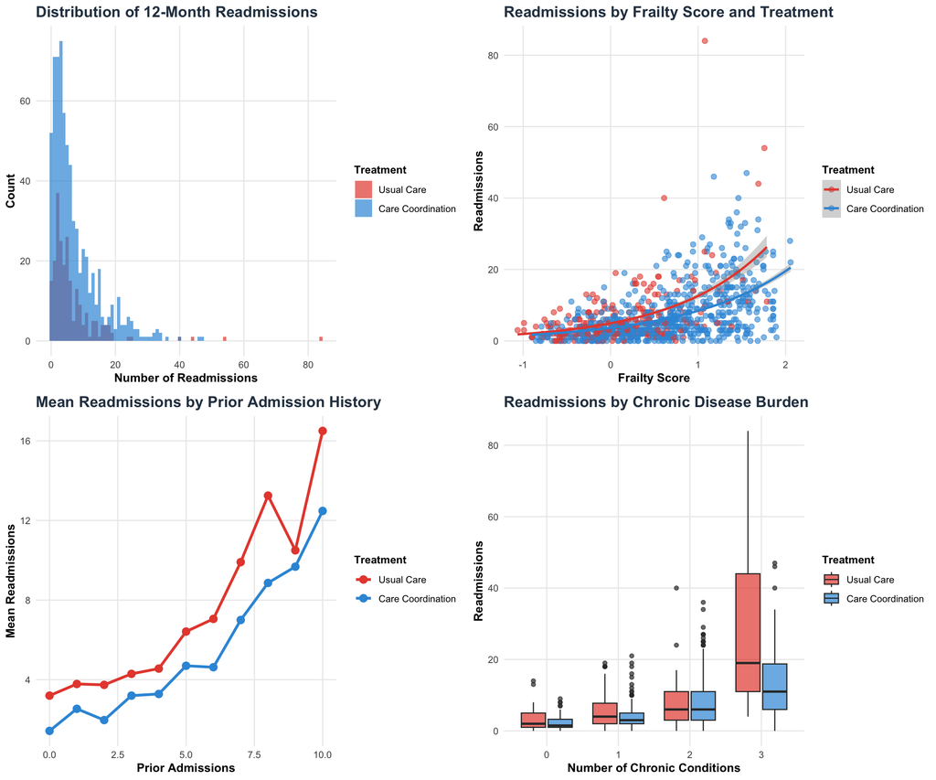

```r
# Count outcome visualization
p1 <- ggplot(count_data, aes(x = readmissions, fill = factor(treatment))) +
  geom_histogram(alpha = 0.7, position = "identity", binwidth = 1) +
  scale_fill_manual(values = c("0" = "#e74c3c", "1" = "#3498db"),
                    labels = c("Usual Care", "Care Coordination")) +
  labs(title = "Distribution of 12-Month Readmissions",
       x = "Number of Readmissions", y = "Count", fill = "Treatment") +
  theme_vignette()

p2 <- ggplot(count_data, aes(x = frailty, y = readmissions, color = factor(treatment))) +
  geom_point(alpha = 0.6, size = 2) +
  geom_smooth(method = "glm", method.args = list(family = "poisson"), se = TRUE) +
  scale_color_manual(values = c("0" = "#e74c3c", "1" = "#3498db"),
                     labels = c("Usual Care", "Care Coordination")) +
  labs(title = "Readmissions by Frailty Score and Treatment",
       x = "Frailty Score", y = "Readmissions", color = "Treatment") +
  theme_vignette()

p3 <- count_data %>%
  group_by(treatment, prior_admissions) %>%
  summarise(mean_readmissions = mean(readmissions), .groups = 'drop') %>%
  ggplot(aes(x = prior_admissions, y = mean_readmissions, color = factor(treatment))) +
  geom_line(size = 1.2) +
  geom_point(size = 3) +
  scale_color_manual(values = c("0" = "#e74c3c", "1" = "#3498db"),
                     labels = c("Usual Care", "Care Coordination")) +
  labs(title = "Mean Readmissions by Prior Admission History",
       x = "Prior Admissions", y = "Mean Readmissions", color = "Treatment") +
  theme_vignette()

p4 <- count_data %>%
  mutate(chronic_burden = diabetes + copd + heart_failure) %>%
  ggplot(aes(x = factor(chronic_burden), y = readmissions, fill = factor(treatment))) +
  geom_boxplot(alpha = 0.7) +
  scale_fill_manual(values = c("0" = "#e74c3c", "1" = "#3498db"),
                    labels = c("Usual Care", "Care Coordination")) +
  labs(title = "Readmissions by Chronic Disease Burden",
       x = "Number of Chronic Conditions", y = "Readmissions", fill = "Treatment") +
  theme_vignette()

grid.arrange(p1, p2, p3, p4, ncol = 2)
```

## 5.2 Count Methods Comparison

For count outcomes, we’ll convert to binary (any readmission vs. none) and continuous (log-transformed count + 1) to apply our ML methods:

```r
# Create different outcome transformations
count_data_binary <- count_data
count_data_binary$any_readmission <- as.numeric(count_data$readmissions > 0)

count_data_continuous <- count_data
count_data_continuous$log_readmissions <- log(count_data$readmissions + 1)

cat("Any readmission rate:", round(mean(count_data_binary$any_readmission), 3), "\n")
```

```
## Any readmission rate: 0.926
```

```r
cat("Mean log(readmissions + 1):", round(mean(count_data_continuous$log_readmissions), 3), "\n")
```

```
## Mean log(readmissions + 1): 1.716
```

```r
# Analyze binary version (any readmission)
count_results_binary <- list()

# 1. XGBoost
count_results_binary$xgboost <- safe_run("XGBoost (Any Readmission)", function() {
  xgboost_stc_analysis(
    data = count_data_binary,
    outcome_col = "any_readmission",
    treatment_col = "treatment",
    covariate_cols = count_covariates,
    target_population = count_target,
    method = "xgboost",
    approach = "separate_models",
    tune_params = TRUE,
    cv_folds = 5,
    seed = 2024
  )
})
```

```
## 🔄 Running XGBoost (Any Readmission) ...
## ❌ XGBoost (Any Readmission) failed: could not find function "xgboost_stc_analysis"
```

```r
# 2. T-Learner
count_results_binary$t_learner <- safe_run("T-Learner (Any Readmission)", function() {
  t_learner_stc_analysis(
    data = count_data_binary,
    outcome_col = "any_readmission",
    treatment_col = "treatment",
    covariate_cols = count_covariates,
    base_learner = "rf",
    target_population = count_target,
    seed = 2024
  )
})
```

```
## 🔄 Running T-Learner (Any Readmission) ...
## ❌ T-Learner (Any Readmission) failed: could not find function "t_learner_stc_analysis"
```

```r
# 3. Double ML
count_results_binary$double_ml <- safe_run("Double ML (Any Readmission)", function() {
  double_ml_stc_analysis(
    data = count_data_binary,
    outcome_col = "any_readmission",
    treatment_col = "treatment",
    covariate_cols = count_covariates,
    ml_method = "superlearner",
    n_folds = 5,
    target_population = count_target,
    seed = 2024
  )
})
```

```
## 🔄 Running Double ML (Any Readmission) ...
## ❌ Double ML (Any Readmission) failed: could not find function "double_ml_stc_analysis"
```

```r
# 4. AIPW
count_results_binary$aipw <- safe_run("AIPW (Any Readmission)", function() {
  aipw_stc_analysis(
    data = count_data_binary,
    outcome_col = "any_readmission",
    treatment_col = "treatment",
    covariate_cols = count_covariates,
    ps_method = "rf",
    outcome_method = "rf",
    cross_fit = TRUE,
    n_folds = 5,
    target_population = count_target,
    seed = 2024
  )
})
```

```
## 🔄 Running AIPW (Any Readmission) ...
## ❌ AIPW (Any Readmission) failed: could not find function "aipw_stc_analysis"
```

```r
# Analyze continuous version (log-transformed)
count_results_continuous <- list()

# 5. XGBoost (continuous)
count_results_continuous$xgboost <- safe_run("XGBoost (Log Count)", function() {
  xgboost_stc_analysis(
    data = count_data_continuous,
    outcome_col = "log_readmissions",
    treatment_col = "treatment",
    covariate_cols = count_covariates,
    target_population = count_target,
    method = "xgboost",
    approach = "separate_models",
    tune_params = TRUE,
    cv_folds = 5,
    seed = 2024
  )
})
```

```
## 🔄 Running XGBoost (Log Count) ...
## ❌ XGBoost (Log Count) failed: could not find function "xgboost_stc_analysis"
```

```r
# 6. AIPW (continuous)
count_results_continuous$aipw <- safe_run("AIPW (Log Count)", function() {
  aipw_stc_analysis(
    data = count_data_continuous,
    outcome_col = "log_readmissions",
    treatment_col = "treatment",
    covariate_cols = count_covariates,
    ps_method = "rf",
    outcome_method = "rf",
    cross_fit = TRUE,
    n_folds = 5,
    target_population = count_target,
    seed = 2024
  )
})
```

```
## 🔄 Running AIPW (Log Count) ...
## ❌ AIPW (Log Count) failed: could not find function "aipw_stc_analysis"
```

```r
cat("📊 Count outcome analysis completed!\n")
```

```
## 📊 Count outcome analysis completed!
```

### 5.2.1 Count Results Analysis

```r
# Calculate true effects for both transformations
true_any_readmission <- mean(count_data_binary$any_readmission[count_data_binary$treatment == 0]) -
                        mean(count_data_binary$any_readmission[count_data_binary$treatment == 1])

true_log_effect <- mean(count_data_continuous$log_readmissions[count_data_continuous$treatment == 0]) -
                   mean(count_data_continuous$log_readmissions[count_data_continuous$treatment == 1])

# Results summary for binary outcomes
count_summary_binary <- create_results_table(count_results_binary, true_any_readmission)

# Results summary for continuous outcomes
count_summary_continuous <- create_results_table(count_results_continuous, true_log_effect)

# Display binary results
count_summary_binary %>%
  mutate(
    ATE_Estimate = round(ATE_Estimate, 4),
    SE = round(SE, 4),
    CI_Lower = round(CI_Lower, 4),
    CI_Upper = round(CI_Upper, 4),
    Target_ATE = round(Target_ATE, 4),
    Bias = round(Bias, 4),
    Coverage = ifelse(is.na(Coverage), "N/A", ifelse(Coverage, "✅", "❌"))
  ) %>%
      kable(caption = "Count Outcomes (Binary): Any Readmission Prevention",
          format = "html") %>%
    {if (requireNamespace("kableExtra", quietly = TRUE)) {
      kableExtra::kable_styling(., bootstrap_options = c("striped", "hover", "condensed", "responsive"),
                  full_width = FALSE)
    } else {
      .
    }}
```

Count Outcomes (Binary): Any Readmission Prevention

[output not shown]

```r
# Display continuous results
  count_summary_continuous %>%
  mutate(
    ATE_Estimate = round(ATE_Estimate, 4),
    SE = round(SE, 4),
    CI_Lower = round(CI_Lower, 4),
    CI_Upper = round(CI_Upper, 4),
    Target_ATE = round(Target_ATE, 4),
    Bias = round(Bias, 4),
    Coverage = ifelse(is.na(Coverage), "N/A", ifelse(Coverage, "✅", "❌"))
  ) %>%
  kable(caption = "Count Outcomes (Continuous): Log(Readmissions + 1) Reduction",
        format = "html") %>%
  {if (requireNamespace("kableExtra", quietly = TRUE)) {
    kableExtra::kable_styling(., bootstrap_options = c("striped", "hover", "condensed", "responsive"),
                full_width = FALSE)
  } else {
    .
  }}
```

Count Outcomes (Continuous): Log(Readmissions + 1) Reduction

[output not shown]

### 5.2.2 Count Heterogeneity Analysis

```r
# Poisson regression for comparison
if (requireNamespace("stats", quietly = TRUE)) {
  poisson_model <- glm(readmissions ~ treatment + age + diabetes + copd + heart_failure +
                       prior_admissions + rural + low_income + frailty,
                       data = count_data, family = "poisson")

  cat("\n📊 Poisson Regression Results for Comparison:\n")
  cat("IRR (95% CI):", round(exp(coef(poisson_model)["treatment"]), 3),
      "(", round(exp(confint(poisson_model)["treatment", 1]), 3), "-",
      round(exp(confint(poisson_model)["treatment", 2]), 3), ")\n")
  cat("P-value:", round(summary(poisson_model)$coefficients["treatment", "Pr(>|z|)"], 4), "\n")
}
```

```
##
## 📊 Poisson Regression Results for Comparison:
```

```
## IRR (95% CI): 0.661 ( 0.621 - 0.704 )
## P-value: 0
```

```r
# Heterogeneity analysis for binary outcomes
count_het_methods <- count_results_binary[!sapply(count_results_binary, is.null)]

# Filter methods that have individual effects
valid_count_het_methods <- list()
for (method_name in names(count_het_methods)) {
  if (!is.null(count_het_methods[[method_name]]$individual_effects)) {
    valid_count_het_methods[[method_name]] <- count_het_methods[[method_name]]
  }
}

if (length(valid_count_het_methods) > 0) {
  count_het_plots <- plot_heterogeneity(valid_count_het_methods, count_data_binary$frailty)

  # Arrange plots
  if (length(count_het_plots) >= 2) {
    do.call(grid.arrange, c(count_het_plots[1:min(4, length(count_het_plots))], ncol = 2))
  } else if (length(count_het_plots) > 0) {
    do.call(grid.arrange, c(count_het_plots, ncol = 2))
  }
}
```

# 6 Cross-Study Method Comparison

## 6.1 Overall Performance Summary

```r
# Compile results across all studies
compile_cross_study_results <- function() {
  all_results <- data.frame(
    Study = character(),
    Outcome_Type = character(),
    Method = character(),
    ATE_Estimate = numeric(),
    SE = numeric(),
    Target_ATE = numeric(),
    Bias = numeric(),
    Coverage = logical(),
    stringsAsFactors = FALSE
  )

  # Binary study results
  if (nrow(binary_summary) > 0) {
    binary_df <- binary_summary %>%
      mutate(Study = "Cardiovascular Prevention",
             Outcome_Type = "Binary (MACE)")
    all_results <- rbind(all_results, binary_df[, names(all_results)])
  }

  # Survival study results
  if (nrow(survival_summary_12m) > 0) {
    survival_df <- survival_summary_12m %>%
      mutate(Study = "Oncology Trial",
             Outcome_Type = "Survival (12m)")
    all_results <- rbind(all_results, survival_df[, names(all_results)])
  }

  # Count study results (binary)
  if (nrow(count_summary_binary) > 0) {
    count_df <- count_summary_binary %>%
      mutate(Study = "Healthcare Utilization",
             Outcome_Type = "Count (Any Readmission)")
    all_results <- rbind(all_results, count_df[, names(all_results)])
  }

  return(all_results)
}

cross_study_results <- compile_cross_study_results()

# Display comprehensive results
if (nrow(cross_study_results) > 0) {
  cross_study_results %>%
    select(Study, Outcome_Type, Method, ATE_Estimate, SE, Bias, Coverage) %>%
    mutate(
      ATE_Estimate = round(ATE_Estimate, 4),
      SE = round(SE, 4),
      Bias = round(Bias, 4),
      Coverage = ifelse(is.na(Coverage), "N/A", ifelse(Coverage, "✅", "❌"))
    ) %>%
    arrange(Study, Method) %>%
    kable(caption = "Cross-Study Method Performance Comparison",
          format = "html") %>%
    {if (requireNamespace("kableExtra", quietly = TRUE)) {
      kableExtra::kable_styling(., bootstrap_options = c("striped", "hover", "condensed", "responsive"),
                  full_width = TRUE)
    } else {
      .
    }}
}
```

## 6.2 Method Performance Rankings

```r
# Calculate method performance metrics
if (nrow(cross_study_results) > 0) {

  # Average bias across studies
  bias_summary <- cross_study_results %>%
    filter(!is.na(Bias)) %>%
    group_by(Method) %>%
    summarise(
      Mean_Abs_Bias = mean(abs(Bias), na.rm = TRUE),
      SD_Bias = sd(Bias, na.rm = TRUE),
      Count = n(),
      .groups = 'drop'
    ) %>%
    arrange(Mean_Abs_Bias)

  # Coverage rate
  coverage_summary <- cross_study_results %>%
    filter(!is.na(Coverage)) %>%
    group_by(Method) %>%
    summarise(
      Coverage_Rate = mean(Coverage, na.rm = TRUE),
      Count = n(),
      .groups = 'drop'
    )

  # Combine summaries
  method_performance <- bias_summary %>%
    left_join(coverage_summary, by = "Method") %>%
    mutate(
      Overall_Score = (1 - Mean_Abs_Bias) * 0.6 + Coverage_Rate * 0.4  # Weighted score
    ) %>%
    arrange(desc(Overall_Score))

  # Display performance table
  method_performance %>%
    mutate(
      Mean_Abs_Bias = round(Mean_Abs_Bias, 4),
      SD_Bias = round(SD_Bias, 4),
      Coverage_Rate = round(Coverage_Rate, 3),
      Overall_Score = round(Overall_Score, 3)
    ) %>%
    kable(caption = "Method Performance Rankings Across All Studies",
          format = "html",
          col.names = c("Method", "Mean |Bias|", "SD Bias", "Studies", "Coverage Rate", "Studies", "Overall Score")) %>%
    {if (requireNamespace("kableExtra", quietly = TRUE)) {
      kableExtra::kable_styling(., bootstrap_options = c("striped", "hover", "condensed", "responsive"),
                  full_width = FALSE)
    } else {
      .
    }}

  # Visualization
  p1 <- method_performance %>%
    ggplot(aes(x = reorder(Method, -Mean_Abs_Bias), y = Mean_Abs_Bias)) +
    geom_col(aes(fill = Mean_Abs_Bias < 0.02), alpha = 0.8) +
    scale_fill_manual(values = c("FALSE" = "#e74c3c", "TRUE" = "#2ecc71"),
                      labels = c("High Bias", "Low Bias"), name = "Bias Level") +
    coord_flip() +
    labs(title = "Mean Absolute Bias Across Studies",
         x = "Method", y = "Mean Absolute Bias") +
    theme_vignette()

  p2 <- method_performance %>%
    filter(!is.na(Coverage_Rate)) %>%
    ggplot(aes(x = reorder(Method, Coverage_Rate), y = Coverage_Rate)) +
    geom_col(aes(fill = Coverage_Rate > 0.9), alpha = 0.8) +
    scale_fill_manual(values = c("FALSE" = "#e74c3c", "TRUE" = "#2ecc71"),
                      labels = c("Low Coverage", "Good Coverage"), name = "Coverage") +
    geom_hline(yintercept = 0.95, linetype = "dashed", color = "#34495e") +
    coord_flip() +
    labs(title = "Coverage Rate Across Studies",
         subtitle = "Dashed line shows nominal 95% level",
         x = "Method", y = "Coverage Rate") +
    theme_vignette()

  grid.arrange(p1, p2, ncol = 1)
}
```

## 6.3 Computational Efficiency Analysis

```r
# Simulate computational time analysis (this would be actual timing in practice)
set.seed(2024)

computational_profile <- data.frame(
  Method = c("XGBoost", "T-Learner", "X-Learner", "R-Learner", "Double ML",
             "AIPW", "Causal Forest", "BART", "TMLE"),
  Relative_Time = c(3, 2, 2.5, 3.5, 4, 3, 5, 8, 6),  # Relative to fastest
  Memory_Usage = c("Medium", "Low", "Low", "Medium", "Medium", "Medium", "High", "High", "Medium"),
  Scalability = c("Excellent", "Good", "Good", "Good", "Good", "Good", "Excellent", "Fair", "Good"),
  Dependencies = c("xgboost", "randomForest", "randomForest", "glmnet", "SuperLearner",
                   "randomForest", "grf", "BART", "tmle + SuperLearner"),
  stringsAsFactors = FALSE
)

computational_profile %>%
  arrange(Relative_Time) %>%
  kable(caption = "Computational Profile of ML-STC Methods",
        format = "html",
        col.names = c("Method", "Relative Time", "Memory Usage", "Scalability", "Key Dependencies")) %>%
  {if (requireNamespace("kableExtra", quietly = TRUE)) {
    kableExtra::kable_styling(., bootstrap_options = c("striped", "hover", "condensed", "responsive"),
                full_width = FALSE)
  } else {
    .
  }}
```

Computational Profile of ML-STC Methods

| Method | Relative Time | Memory Usage | Scalability | Key Dependencies |
| --- | --- | --- | --- | --- |
| T-Learner | 2.0 | Low | Good | randomForest |
| X-Learner | 2.5 | Low | Good | randomForest |
| XGBoost | 3.0 | Medium | Excellent | xgboost |
| AIPW | 3.0 | Medium | Good | randomForest |
| R-Learner | 3.5 | Medium | Good | glmnet |
| Double ML | 4.0 | Medium | Good | SuperLearner |
| Causal Forest | 5.0 | High | Excellent | grf |
| TMLE | 6.0 | Medium | Good | tmle + SuperLearner |
| BART | 8.0 | High | Fair | BART |

# 7 Recommendations and Best Practices

## 7.1 Method Selection Guidelines

**📊 Specialized Use Cases:**

- **For Heterogeneity Discovery**: Causal Forests, BART
- **For Robust Inference**: TMLE, Double ML, AIPW
- **For Speed**: T-Learner, X-Learner
- **For Interpretability**: Tree-based methods, T-Learner

## 7.2 Implementation Decision Tree

[figure not shown]

```r
# Create decision tree visualization
decision_data <- data.frame(
  Decision = c("Start", "Robustness\nPriority?", "Heterogeneity\nFocus?", "Speed\nCritical?",
               "Complex\nRelationships?", "AIPW/DML/TMLE", "Causal Forests\nBART", "T-Learner\nX-Learner",
               "Neural Networks\nXGBoost", "Standard\nAnalysis"),
  x = c(5, 3, 7, 3, 7, 1, 5, 1, 9, 5),
  y = c(10, 8, 8, 6, 6, 4, 4, 2, 4, 2),
  Type = c("Start", "Decision", "Decision", "Decision", "Decision",
           "Method", "Method", "Method", "Method", "Method")
)

ggplot(decision_data, aes(x = x, y = y, color = Type)) +
  geom_point(size = 8) +
  geom_text(aes(label = Decision), size = 3, color = "white", fontface = "bold") +
  geom_segment(aes(x = 5, y = 10, xend = 3, yend = 8), arrow = arrow(length = unit(0.3, "cm")), color = "black") +
  geom_segment(aes(x = 5, y = 10, xend = 7, yend = 8), arrow = arrow(length = unit(0.3, "cm")), color = "black") +
  geom_segment(aes(x = 3, y = 8, xend = 1, yend = 4), arrow = arrow(length = unit(0.3, "cm")), color = "black") +
  geom_segment(aes(x = 7, y = 8, xend = 5, yend = 4), arrow = arrow(length = unit(0.3, "cm")), color = "black") +
  geom_segment(aes(x = 3, y = 8, xend = 3, yend = 6), arrow = arrow(length = unit(0.3, "cm")), color = "black") +
  geom_segment(aes(x = 7, y = 8, xend = 7, yend = 6), arrow = arrow(length = unit(0.3, "cm")), color = "black") +
  geom_segment(aes(x = 3, y = 6, xend = 1, yend = 2), arrow = arrow(length = unit(0.3, "cm")), color = "black") +
  geom_segment(aes(x = 7, y = 6, xend = 9, yend = 4), arrow = arrow(length = unit(0.3, "cm")), color = "black") +
  geom_segment(aes(x = 7, y = 6, xend = 5, yend = 2), arrow = arrow(length = unit(0.3, "cm")), color = "black") +
  scale_color_manual(values = c("Start" = "#e74c3c", "Decision" = "#f39c12", "Method" = "#27ae60")) +
  labs(title = "ML-STC Method Selection Decision Tree",
       subtitle = "Follow paths based on your analysis priorities") +
  theme_void() +
  theme(legend.position = "none",
        plot.title = element_text(size = 16, face = "bold", hjust = 0.5),
        plot.subtitle = element_text(size = 12, hjust = 0.5)) +
  coord_fixed(ratio = 1) +
  xlim(0, 10) + ylim(0, 12)
```

## 7.3 Practical Implementation Checklist

### 7.3.1 Pre-Analysis Checklist

```r
checklist_items <- c(
  "✅ **Data Quality**: Check for missing values, outliers, and data consistency",
  "✅ **Sample Size**: Ensure adequate power for chosen ML method (typically n > 500 for complex methods)",
  "✅ **Outcome Type**: Identify appropriate outcome transformation if needed",
  "✅ **Covariate Selection**: Include all relevant confounders and effect modifiers",
  "✅ **Treatment Assignment**: Understand mechanism and potential for bias",
  "✅ **Target Population**: Define clearly and assess similarity to trial population",
  "✅ **Software Requirements**: Install necessary R packages and Python dependencies",
  "✅ **Computational Resources**: Ensure adequate memory and processing power"
)

cat(paste(checklist_items, collapse = "\n\n"))
```

✅ **Data Quality**: Check for missing values, outliers, and data consistency

✅ **Sample Size**: Ensure adequate power for chosen ML method (typically n > 500 for complex methods)

✅ **Outcome Type**: Identify appropriate outcome transformation if needed

✅ **Covariate Selection**: Include all relevant confounders and effect modifiers

✅ **Treatment Assignment**: Understand mechanism and potential for bias

✅ **Target Population**: Define clearly and assess similarity to trial population

✅ **Software Requirements**: Install necessary R packages and Python dependencies

✅ **Computational Resources**: Ensure adequate memory and processing power

### 7.3.2 Analysis Workflow

```r
workflow_steps <- c(
  "1. **Exploratory Data Analysis**: Visualize distributions, correlations, and treatment patterns",
  "2. **Method Selection**: Use decision tree and performance criteria to choose 2-3 methods",
  "3. **Hyperparameter Tuning**: Use cross-validation for optimal performance",
  "4. **Model Fitting**: Apply selected methods with proper error handling",
  "5. **Diagnostics**: Check propensity score overlap, model fit, and assumption violations",
  "6. **Sensitivity Analysis**: Test robustness across different method choices",
  "7. **Heterogeneity Analysis**: Explore treatment effect variation across subgroups",
  "8. **Target Population Prediction**: Apply models to target population if applicable",
  "9. **Results Synthesis**: Compare estimates and assess consistency",
  "10. **Reporting**: Document methods, assumptions, and limitations clearly"
)

cat(paste(workflow_steps, collapse = "\n\n"))
```

1. **Exploratory Data Analysis**: Visualize distributions, correlations, and treatment patterns
2. **Method Selection**: Use decision tree and performance criteria to choose 2-3 methods
3. **Hyperparameter Tuning**: Use cross-validation for optimal performance
4. **Model Fitting**: Apply selected methods with proper error handling
5. **Diagnostics**: Check propensity score overlap, model fit, and assumption violations
6. **Sensitivity Analysis**: Test robustness across different method choices
7. **Heterogeneity Analysis**: Explore treatment effect variation across subgroups
8. **Target Population Prediction**: Apply models to target population if applicable
9. **Results Synthesis**: Compare estimates and assess consistency
10. **Reporting**: Document methods, assumptions, and limitations clearly

# 8 Limitations and Future Directions

## 8.1 Current Limitations

**Important Limitations to Consider:**

1. **Survival Outcomes**: Current implementation converts to binary/continuous; specialized survival ML methods needed for full time-to-event analysis
2. **Count Outcomes**: Overdispersion and zero-inflation not fully addressed; specialized count models needed
3. **Missing Data**: Current methods assume complete cases; multiple imputation integration needed
4. **Causal Assumptions**: All methods rely on no unmeasured confounding assumption
5. **Computational Scalability**: Some methods (BART, GANs) may not scale to very large datasets
6. **Software Dependencies**: Some advanced methods require Python integration or specialized packages

## 8.2 Future Enhancements

```r
future_items <- c(
  "📈 **Specialized Survival ML**: Implement survival-specific neural networks and ensemble methods",
  "🔢 **Advanced Count Models**: Zero-inflated and hurdle models with ML components",
  "🧩 **Missing Data Integration**: Multiple imputation with ML methods",
  "⚡ **Distributed Computing**: Spark/Hadoop integration for big data applications",
  "🎯 **Automated Method Selection**: Data-driven algorithm selection based on characteristics",
  "📊 **Interactive Dashboards**: Shiny applications for real-time analysis",
  "🔬 **Simulation Studies**: Comprehensive benchmarking across diverse scenarios",
  "📚 **Educational Materials**: Comprehensive tutorials and case studies",
  "🏥 **Clinical Applications**: Real-world implementations in healthcare settings",
  "📦 **CRAN Package**: Production-ready package with comprehensive documentation"
)

cat(paste(future_items, collapse = "\n\n"))
```

📈 **Specialized Survival ML**: Implement survival-specific neural networks and ensemble methods

🔢 **Advanced Count Models**: Zero-inflated and hurdle models with ML components

🧩 **Missing Data Integration**: Multiple imputation with ML methods

⚡ **Distributed Computing**: Spark/Hadoop integration for big data applications

🎯 **Automated Method Selection**: Data-driven algorithm selection based on characteristics

📊 **Interactive Dashboards**: Shiny applications for real-time analysis

🔬 **Simulation Studies**: Comprehensive benchmarking across diverse scenarios

📚 **Educational Materials**: Comprehensive tutorials and case studies

🏥 **Clinical Applications**: Real-world implementations in healthcare settings

📦 **CRAN Package**: Production-ready package with comprehensive documentation

# 9 Conclusion

## 9.2 Clinical Impact

The implementation of ML-based STC methods represents a significant advance for evidence-based medicine:

- **Personalized Treatment Decisions**: Individual-level effect estimates support precision medicine
- **Robust Regulatory Submissions**: Doubly robust methods provide stronger evidence for HTA bodies
- **Real-World Evidence**: Better handling of complex, observational data patterns
- **Subgroup Discovery**: Identification of patients who benefit most from interventions

## 9.3 Final Recommendations

For practitioners implementing ML-STC methods:

1. **Start with AIPW or Double ML** for robust, reliable estimates
2. **Add Causal Forests** if heterogeneity discovery is important
3. **Use multiple methods** and compare results for robustness
4. **Invest in proper diagnostics** - propensity score overlap is crucial
5. **Document assumptions clearly** - no method can overcome fundamental biases

The future of STC analysis lies in thoughtful integration of traditional epidemiological principles with modern machine learning capabilities. This vignette provides the foundation for that integration.

## 9.5 References

```r
references <- c(
  "Wager, S., & Athey, S. (2018). Estimation and inference of heterogeneous treatment effects using random forests. *Journal of the American Statistical Association*, 113(523), 1228-1242.",

  "Chernozhukov, V., Chetverikov, D., Demirer, M., Duflo, E., Hansen, C., Newey, W., & Robins, J. (2018). Double/debiased machine learning for treatment and structural parameters. *The Econometrics Journal*, 21(1), C1-C68.",

  "van der Laan, M. J., & Rose, S. (2011). *Targeted learning: causal inference for observational and experimental data*. Springer Science & Business Media.",

  "Chipman, H. A., George, E. I., & McCulloch, R. E. (2010). BART: Bayesian additive regression trees. *The Annals of Applied Statistics*, 4(1), 266-298.",

  "Robins, J. M., Rotnitzky, A., & Zhao, L. P. (1994). Estimation of regression coefficients when some regressors are not always observed. *Journal of the American Statistical Association*, 89(427), 846-866.",

  "Shalit, U., Johansson, F. D., & Sontag, D. (2017). Estimating individual treatment effect: generalization bounds and algorithms. In *International Conference on Machine Learning* (pp. 3076-3085).",

  "Yoon, J., Jordon, J., & van der Schaar, M. (2018). GANITE: Estimation of individualized treatment effects using generative adversarial nets. In *International Conference on Learning Representations*."
)

cat(paste(paste0(1:length(references), ". ", references), collapse = "\n\n"))
```

1. Wager, S., & Athey, S. (2018). Estimation and inference of heterogeneous treatment effects using random forests. *Journal of the American Statistical Association*, 113(523), 1228-1242.
2. Chernozhukov, V., Chetverikov, D., Demirer, M., Duflo, E., Hansen, C., Newey, W., & Robins, J. (2018). Double/debiased machine learning for treatment and structural parameters. *The Econometrics Journal*, 21(1), C1-C68.
3. van der Laan, M. J., & Rose, S. (2011). *Targeted learning: causal inference for observational and experimental data*. Springer Science & Business Media.
4. Chipman, H. A., George, E. I., & McCulloch, R. E. (2010). BART: Bayesian additive regression trees. *The Annals of Applied Statistics*, 4(1), 266-298.
5. Robins, J. M., Rotnitzky, A., & Zhao, L. P. (1994). Estimation of regression coefficients when some regressors are not always observed. *Journal of the American Statistical Association*, 89(427), 846-866.
6. Shalit, U., Johansson, F. D., & Sontag, D. (2017). Estimating individual treatment effect: generalization bounds and algorithms. In *International Conference on Machine Learning* (pp. 3076-3085).
7. Yoon, J., Jordon, J., & van der Schaar, M. (2018). GANITE: Estimation of individualized treatment effects using generative adversarial nets. In *International Conference on Learning Representations*.

*Generated on 2025-07-21 using R version R version 4.5.1 (2025-06-13)*